# Combining plots using grid and gridExtra

PS239T

21 October, 2019

## Purpose

This document shows how to use the `grid` and `gridExtra` packages to combine multiple plots.

For example data, it uses Anscombe’s quartet:

- “Anscombe’s quartet comprises four data sets that have nearly identical simple descriptive statistics, yet have very different distributions and appear very different when graphed. Each dataset consists of eleven (x,y) points. They were constructed in 1973 by the statistician Francis Anscombe to demonstrate both the importance of graphing data before analyzing it and the effect of outliers and other influential observations on statistical properties.” ([source: Wikipedia](https://en.wikipedia.org/wiki/Anscombe's_quartet))

# 1) SET UP

## 1.1. Setup environment

```r
# remove all objects
rm(list=ls())

# check working directory
getwd()
```

```
## [1] "C:/Users/Julia/OneDrive/Documents/Berkeley/2019-08_Fall/PS239T_Fall2019/09_r-analysis-visualization/P1_ggplot-basics/Analysis"
```

```r
# Unload all packages
library(pacman)
pacman::p_unload(all)
```

```
## The following packages have been unloaded:
## pacman
```

```r
# Add packages
pacman::p_load(
  tidyverse, #ggplot, dplyr, readr, etc.
  ggthemes, #great colors
  grid, gridExtra #combine plots
)
```

## 1.2. Load data

Anscombe’s quartet is available as a built-in dataset in R.

```r
require(stats); require(graphics)
summary(anscombe)
```

```
##        x1             x2             x3             x4
##  Min.   : 4.0   Min.   : 4.0   Min.   : 4.0   Min.   : 8
##  1st Qu.: 6.5   1st Qu.: 6.5   1st Qu.: 6.5   1st Qu.: 8
##  Median : 9.0   Median : 9.0   Median : 9.0   Median : 8
##  Mean   : 9.0   Mean   : 9.0   Mean   : 9.0   Mean   : 9
##  3rd Qu.:11.5   3rd Qu.:11.5   3rd Qu.:11.5   3rd Qu.: 8
##  Max.   :14.0   Max.   :14.0   Max.   :14.0   Max.   :19
##        y1               y2              y3              y4
##  Min.   : 4.260   Min.   :3.100   Min.   : 5.39   Min.   : 5.250
##  1st Qu.: 6.315   1st Qu.:6.695   1st Qu.: 6.25   1st Qu.: 6.170
##  Median : 7.580   Median :8.140   Median : 7.11   Median : 7.040
##  Mean   : 7.501   Mean   :7.501   Mean   : 7.50   Mean   : 7.501
##  3rd Qu.: 8.570   3rd Qu.:8.950   3rd Qu.: 7.98   3rd Qu.: 8.190
##  Max.   :10.840   Max.   :9.260   Max.   :12.74   Max.   :12.500
```

### 1.3. Visualization set up

```r
# Change default plot dimensions
knitr::opts_chunk$set(fig.width=10, fig.height=6)

# Save theme (like theme_ed but without gridlines)
theme_jc <- theme(
  legend.position = "bottom",
  panel.background = element_rect(fill = NA),
  panel.border = element_rect(fill = NA, color = "grey75"),
  axis.ticks = element_line(color = "grey85"),
  panel.grid.major = element_line(color = NA), #no gridlines
  panel.grid.minor = element_line(color = NA), #no gridlines
  legend.key = element_blank())
```

# 2) PLOT QUARTET

## 2.1. Generate seperate plots

First, try basic plot of x1 and y1.

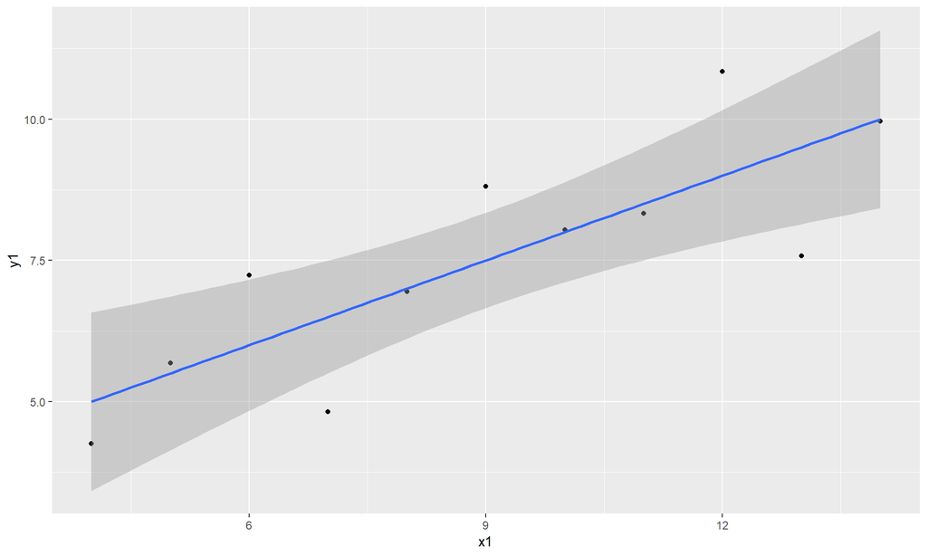

```r
anscombe %>%
  ggplot(aes(x=x1, y=y1)) +
  geom_point() +
  geom_smooth(method='lm')
```

Then make it a little cleaner…

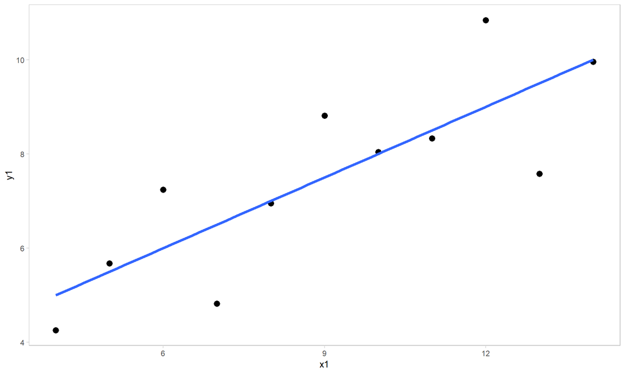

```r
anscombe %>%
  ggplot(aes(x=x1, y=y1)) +
  geom_point(size=3) +
  geom_smooth(method='lm', se=FALSE, size=1.5) +
  theme_jc
```

Now, modify the code so that it is a function.

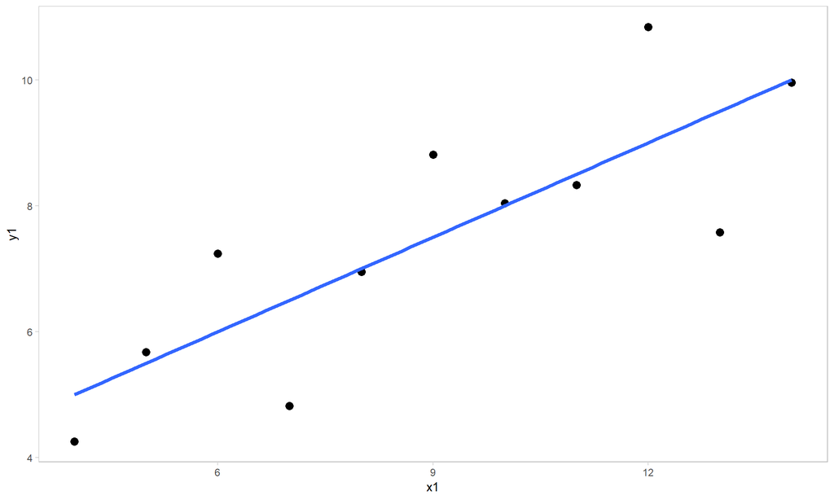

```r
gen_plot <- function(dat, num)
{
  dat %>%
    ggplot(aes_string(x=paste0("x",num),
                      y=paste0("y",num)
                      )) +
      geom_point(size=3) +
      geom_smooth(method='lm', se=FALSE, size=1.5) +
      theme_jc
}

gen_plot(anscombe, num=1)
```

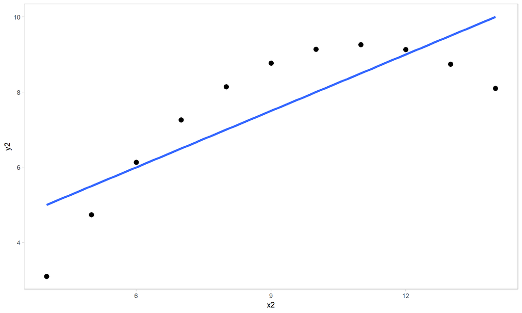

```r
gen_plot(anscombe, num=2)
```

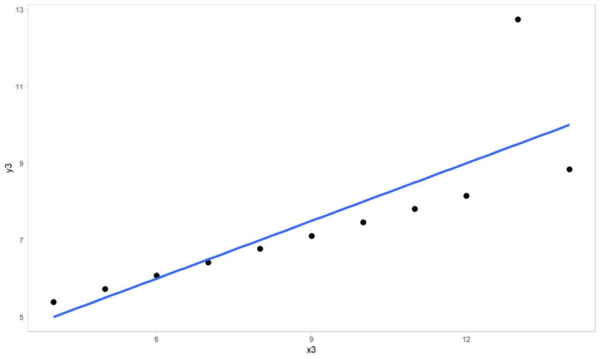

```r
gen_plot(anscombe, num=3)
```

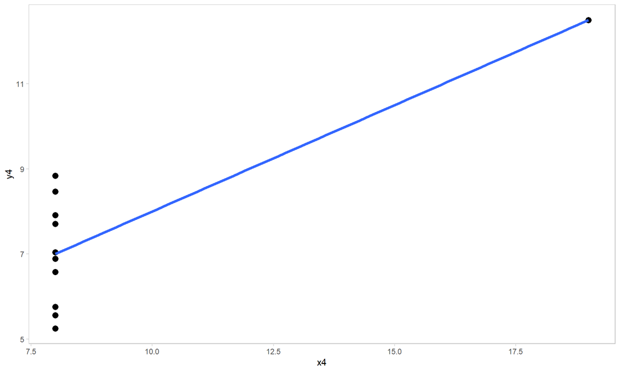

```r
gen_plot(anscombe, num=4)
```

Save all 4 sets of x and y variables.

```r
a1 <- gen_plot(anscombe, num=1)
a2 <- gen_plot(anscombe, num=2)
a3 <- gen_plot(anscombe, num=3)
a4 <- gen_plot(anscombe, num=4)
```

## 2.2. Combine plots together

We can use `arrangeGrob()` to combine these plots together.

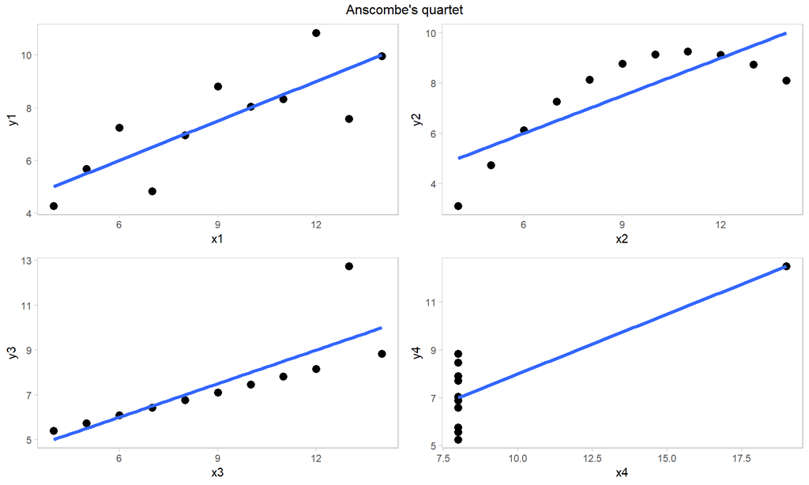

```r
# Create object with combined plot
anscombe_quartet <- arrangeGrob(a1, a2, a3, a4,
  # Two columns
  ncol = 2,
  # Title on top
  top = "Anscombe's quartet")

# Print the grid the screen (Option 1)
grid.draw(anscombe_quartet)
```

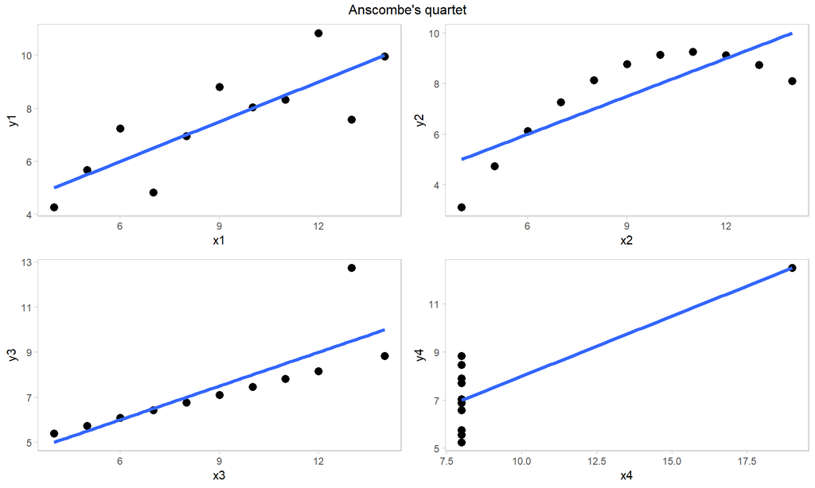

```r
# Print the grid the screen (Option 2)
grid.arrange(anscombe_quartet)
```

Note that we could have looped through each plot as follows, avoiding unnecessary objects and lines of code.

```r
# Loop through all 4 sets of x and y variables.
p <- map(c(1:4), function(x) gen_plot(anscombe, x))

# Check results
p

# Combine plot
anscombe_quartet <- arrangeGrob(p[[1]], p[[2]], p[[3]], p[[4]],
  # Two columns
  ncol = 2,
  # Title on top
  top = "Anscombe's quartet")

# Print the grid the screen (Option 1)
grid.draw(anscombe_quartet)

# Print the grid the screen (Option 2)
grid.arrange(anscombe_quartet)
```